# Film Rental Demand Analysis

Analisis Regresi Linear Berganda & K-Means Clustering pada Database Sakila

Aneira Nasywa Azalia - M0724021

2026-05-26

# Pendahuluan

Di era industri hiburan yang terus bergeser ke platform digital, bisnis penyewaan film berbasis fisik dituntut untuk beroperasi dengan efisiensi yang jauh lebih tinggi dari sebelumnya. Keberhasilan sebuah toko penyewaan tidak lagi cukup hanya ditopang oleh ketersediaan judul yang banyak — melainkan oleh seberapa dalam pengelola memahami **dinamika permintaan film**: judul mana yang paling sering disewa, atribut film apa yang mendorong permintaan, dan bagaimana portofolio film dapat disegmentasi untuk pengambilan keputusan yang lebih strategis.

Untuk menjawab tantangan tersebut, analisis ini mengadopsi dua pendekatan kuantitatif yang saling melengkapi: **Regresi Linear Berganda** untuk mengidentifikasi faktor-faktor yang secara statistik signifikan memengaruhi tingginya permintaan sewa suatu film, dan **K-Means Clustering** untuk mengelompokkan film ke dalam segmen-segmen strategis berdasarkan karakteristik numeriknya. Kedua metode ini dirangkum pada tabel berikut:

Ringkasan Metode Analisis yang Digunakan

| Metode | Definisi | Output yang Diharapkan |
| --- | --- | --- |
| Regresi Linear Berganda | Metode statistik untuk memodelkan hubungan antara satu variabel dependen dengan dua atau lebih variabel independen | Koefisien & tingkat signifikansi tiap prediktor terhadap jumlah rental |
| K-Means Clustering | Algoritma unsupervised learning yang mengelompokkan observasi ke dalam k klaster berdasarkan kedekatan jarak Euclidean | Label segmen film: Premium Popular, Budget Underrated, dll. |

Kegunaan utama dari kombinasi kedua metode ini adalah kemampuannya memberikan pemahaman berlapis: regresi menjawab **“mengapa”** suatu film banyak disewa, sementara clustering menjawab **“film mana”** yang perlu diprioritaskan secara bisnis.

Analisis ini diimplementasikan menggunakan **Database Sakila**, sebuah basis data sampel relasional standar dari MySQL yang mensimulasikan sistem operasional bisnis penyewaan DVD. Database ini sangat representatif dan ideal untuk analisis permintaan film karena tiga alasan utama:

1. **Data Transaksi yang Granular:** Sakila memiliki tabel operasional seperti `rental` dan `payment` yang mencatat setiap transaksi sewa secara lengkap dengan *timestamp*, memungkinkan agregasi jumlah permintaan per film secara presisi.
2. **Atribut Film yang Kaya sebagai Prediktor:** Tabel `film` menyediakan variabel numerik seperti `rental_rate`, `length`, `rental_duration`, dan `replacement_cost` yang dapat dijadikan variabel independen, dilengkapi dengan variabel tambahan `total_stok` dari tabel `inventory` dan `total_aktor` dari tabel `film_actor`.
3. **Hierarki Kategori yang Terstruktur:** Relasi antar tabel `film` → `film_category` → `category` memungkinkan analisis permintaan di-*breakdown* per genre sehingga insight yang dihasilkan lebih kontekstual.

Tabel Database Sakila yang Digunakan dalam Analisis

| Tabel | Deskripsi | Variabel Kunci |
| --- | --- | --- |
| film | Atribut film: judul, rating, durasi, harga sewa, biaya penggantian | film_id, rental_rate, length, rental_duration, replacement_cost |
| film_category | Tabel bridge penghubung film dengan genre | film_id, category_id |
| category | Nama genre film (Action, Comedy, Drama, dll.) | category_id, name |
| inventory | Stok fisik film yang tersedia di toko | inventory_id, film_id |
| rental | Riwayat transaksi penyewaan film oleh pelanggan | rental_id, inventory_id |
| film_actor | Relasi film dengan aktor yang membintanginya | film_id, actor_id |

## Rumusan Masalah

Berdasarkan latar belakang di atas, analisis ini berfokus pada tiga pertanyaan utama:

1. Apakah atribut film seperti `rental_rate`, `length`, `rental_duration`, `replacement_cost`, `total_stok`, dan `total_aktor` secara statistik signifikan memengaruhi **jumlah permintaan sewa** (*total_rental*) suatu film?
2. Bagaimana film-film dalam database Sakila dapat dikelompokkan ke dalam **segmen strategis** yang bermakna secara bisnis berdasarkan popularitas dan karakteristik harganya?
3. Rekomendasi bisnis apa yang dapat diberikan kepada pengelola toko berdasarkan temuan dari kedua metode analisis tersebut?

## Tujuan Analisis

Penelitian dan analisis ini bertujuan untuk:

1. Mengekstrak dan mengagregasi data dari tabel `film`, `inventory`, `rental`, `film_actor`, dan `film_category` pada database Sakila untuk membentuk satu dataset analitik yang siap dimodelkan, dengan `total_rental` sebagai ukuran permintaan utama.
2. Membangun **model regresi linear berganda** guna mengidentifikasi variabel atribut film yang secara signifikan memengaruhi tingginya permintaan sewa, dilengkapi dengan uji asumsi klasik meliputi *multikolinearitas* (GVIF), *heteroskedastisitas* (Breusch-Pagan), *normalitas residual* (Kolmogorov-Smirnov), *autokorelasi* (Durbin-Watson), dan *linearitas* (Rainbow Test).
3. Menerapkan algoritma **K-Means Clustering** untuk mengelompokkan film ke dalam segmen-segmen yang dapat ditindaklanjuti secara bisnis, dengan penentuan jumlah klaster optimal menggunakan metode *Elbow* dan indeks *Silhouette*.
4. Merumuskan **rekomendasi strategi pengelolaan portofolio film** — mencakup pengadaan stok, penetapan harga sewa, dan prioritas promosi — berdasarkan temuan dari kedua metode analisis tersebut.

# Setup & Pengambilan Data

Langkah pertama adalah membangun koneksi antara RStudio dan database MySQL menggunakan fungsi `dbConnect()` dari package `DBI`. Koneksi dilakukan melalui driver ODBC yang menghubungkan R secara langsung ke database **Sakila** yang berjalan di server lokal (*localhost*).

## Pengambilan Data

Langkah selanjutnya adalah mengekstrak data film beserta jumlah total penyewaan dari database Sakila. Data diambil dengan menggabungkan beberapa tabel melalui operasi `JOIN`, yaitu tabel `film`, `film_category`, `category`, `inventory`, `rental`, dan `film_actor`.

Variabel yang diambil adalah sebagai berikut:

- `film_id` & `title` — identitas film
- `genre` — kategori/genre film dari tabel `category`
- `rental_rate` — harga sewa per periode
- `length` — durasi film dalam menit
- `rental_duration` — batas waktu pengembalian (hari)
- `replacement_cost` — biaya penggantian jika film hilang/rusak
- `rating` — rating film (G, PG, PG-13, R, NC-17)
- `total_rental` — **variabel dependen**, total berapa kali film disewa
- `total_stok` — jumlah stok fisik film di seluruh toko
- `total_aktor` — jumlah aktor yang membintangi film Secara matematis, variabel dependen didefinisikan sebagai:

$$total\_rental_i = \sum_{j=1}^{n}
\mathbf{1}[\text{rental}_j \text{ merujuk pada film } i]$$

```r
q_film <- "
  SELECT
    f.film_id,
    f.title,
    c.name                         AS genre,
    f.rental_rate,
    f.length,
    f.rental_duration,
    f.replacement_cost,
    f.rating,
    COUNT(DISTINCT r.rental_id)    AS total_rental,
    COUNT(DISTINCT i.inventory_id) AS total_stok,
    COUNT(DISTINCT fa.actor_id)    AS total_aktor
  FROM film f
  JOIN film_category fc ON f.film_id      = fc.film_id
  JOIN category      c  ON fc.category_id = c.category_id
  JOIN inventory     i  ON f.film_id      = i.film_id
  JOIN rental        r  ON i.inventory_id = r.inventory_id
  JOIN film_actor    fa ON f.film_id      = fa.film_id
  GROUP BY
    f.film_id, f.title, c.name,
    f.rental_rate, f.length,
    f.rental_duration, f.replacement_cost, f.rating
"

df_film <- dbGetQuery(con1, q_film)

# Fix tipe data
df_film$total_rental <- as.numeric(df_film$total_rental)
df_film$total_stok   <- as.numeric(df_film$total_stok)
df_film$total_aktor  <- as.numeric(df_film$total_aktor)
```

Berikut adalah cuplikan data mentah yang berhasil diekstrak:

Cuplikan 10 Baris Pertama Data Film

| film_id | title | genre | rental_rate | length | rental_duration | replacement_cost | rating | total_rental | total_stok | total_aktor |
| --- | --- | --- | --- | --- | --- | --- | --- | --- | --- | --- |
| 1 | ACADEMY DINOSAUR | Documentary | 0.99 | 86 | 6 | 20.99 | PG | 23 | 7 | 10 |
| 2 | ACE GOLDFINGER | Horror | 4.99 | 48 | 3 | 12.99 | G | 7 | 3 | 4 |
| 3 | ADAPTATION HOLES | Documentary | 2.99 | 50 | 7 | 18.99 | NC-17 | 12 | 4 | 5 |
| 4 | AFFAIR PREJUDICE | Horror | 2.99 | 117 | 5 | 26.99 | G | 23 | 7 | 5 |
| 5 | AFRICAN EGG | Family | 2.99 | 130 | 6 | 22.99 | G | 12 | 3 | 5 |
| 6 | AGENT TRUMAN | Foreign | 2.99 | 169 | 3 | 17.99 | PG | 21 | 6 | 7 |
| 7 | AIRPLANE SIERRA | Comedy | 4.99 | 62 | 6 | 28.99 | PG-13 | 15 | 5 | 5 |
| 8 | AIRPORT POLLOCK | Horror | 4.99 | 54 | 6 | 15.99 | R | 18 | 4 | 4 |
| 9 | ALABAMA DEVIL | Horror | 2.99 | 114 | 3 | 21.99 | PG-13 | 12 | 5 | 9 |
| 10 | ALADDIN CALENDAR | Sports | 4.99 | 63 | 6 | 24.99 | NC-17 | 23 | 7 | 8 |

# Analisis & Temuan

Sebelum masuk ke pemodelan, dilakukan eksplorasi awal terhadap dataset untuk memahami distribusi, rentang nilai, dan karakteristik dasar setiap variabel.

## Statistik Deskriptif

```r
df_num <- df_film %>%
  select(rental_rate, length, rental_duration,
         replacement_cost, total_stok, total_aktor, total_rental)

stat_desk <- data.frame(
  Variabel = names(df_num),
  Min      = round(sapply(df_num, min), 2),
  Max      = round(sapply(df_num, max), 2),
  Mean     = round(sapply(df_num, mean), 2),
  Median   = round(sapply(df_num, median), 2),
  SD       = round(sapply(df_num, sd), 2),
  Skewness = round(sapply(df_num, function(x) {
               mean((x - mean(x))^3) / sd(x)^3}), 2)
)

kable(stat_desk, caption = "Statistik Deskriptif Variabel Numerik",
      row.names = FALSE) %>%
  kable_styling(
    bootstrap_options = c("striped", "hover", "bordered"),
    full_width        = TRUE,
    position          = "left"
  ) %>%
  column_spec(1, bold = TRUE, monospace = TRUE, color = "#e94560") %>%
  row_spec(0, bold = TRUE, color = "white", background = "#16213e")
```

Statistik Deskriptif Variabel Numerik

| Variabel | Min | Max | Mean | Median | SD | Skewness |
| --- | --- | --- | --- | --- | --- | --- |
| rental_rate | 0.99 | 4.99 | 2.98 | 2.99 | 1.64 | 0.01 |
| length | 46.00 | 185.00 | 115.36 | 114.00 | 40.43 | 0.03 |
| rental_duration | 3.00 | 7.00 | 4.97 | 5.00 | 1.41 | 0.01 |
| replacement_cost | 9.99 | 29.99 | 20.05 | 19.99 | 6.06 | -0.01 |
| total_stok | 2.00 | 8.00 | 4.78 | 5.00 | 1.82 | 0.05 |
| total_aktor | 1.00 | 15.00 | 5.49 | 5.00 | 2.31 | 0.47 |
| total_rental | 4.00 | 34.00 | 16.76 | 16.00 | 6.68 | 0.19 |

## Visualisasi Distribusi

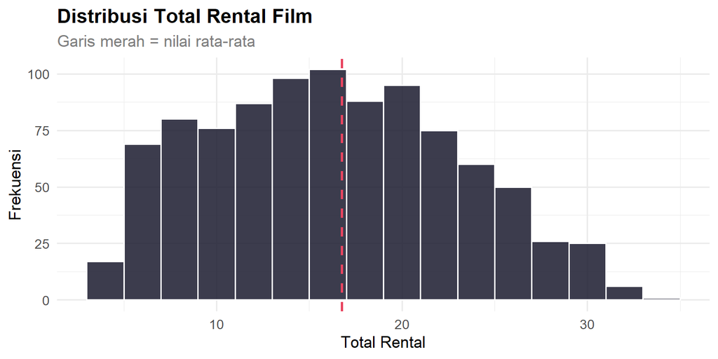

```r
ggplot(df_film, aes(x = total_rental)) +
  geom_histogram(binwidth = 2, fill = "#1a1a2e", color = "white",
                 alpha = 0.85) +
  geom_vline(aes(xintercept = mean(total_rental)),
             color = "#e94560", linetype = "dashed", linewidth = 1) +
  labs(
    title    = "Distribusi Total Rental Film",
    subtitle = "Garis merah = nilai rata-rata",
    x        = "Total Rental",
    y        = "Frekuensi"
  ) +
  theme_minimal(base_size = 13) +
  theme(
    plot.title    = element_text(face = "bold"),
    plot.subtitle = element_text(color = "gray50")
  )
```

Histogram menunjukkan distribusi `total_rental` berbentuk mendekati **simetris** (*skewness* = 0.19). Sebagian besar film disewa antara **10 hingga 25 kali** dengan puncak di sekitar rata-rata **16.75 kali**. Kondisi ini baik untuk pemodelan karena variabel dependen tidak terlalu *skewed*.

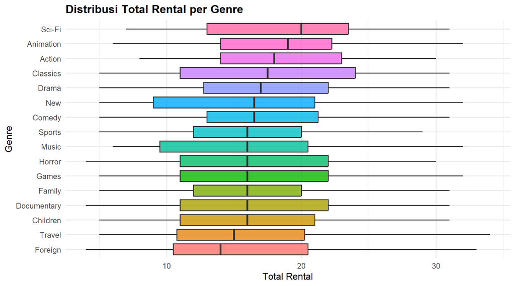

```r
urutan_genre <- df_film %>%
  group_by(genre) %>%
  summarise(med = median(total_rental)) %>%
  arrange(med) %>%
  pull(genre)

df_film$genre_ordered <- factor(df_film$genre, levels = urutan_genre)

ggplot(df_film, aes(x = genre_ordered, y = total_rental,
                    fill = genre_ordered)) +
  geom_boxplot(alpha = 0.8, outlier.colour = "#e94560",
               outlier.size = 2) +
  coord_flip() +
  labs(
    title = "Distribusi Total Rental per Genre",
    x     = "Genre",
    y     = "Total Rental"
  ) +
  theme_minimal(base_size = 12) +
  theme(
    legend.position = "none",
    plot.title      = element_text(face = "bold")
  )
```

Boxplot menunjukkan tidak terdapat perbedaan drastis antar genre — hampir semua genre bermedian di kisaran 15–20 kali rental. **Sci-Fi** memiliki median tertinggi sementara **Foreign** terendah. Genre **Classics** memiliki IQR terlebar menandakan variasi permintaan yang besar. Perbedaan antar genre yang tidak signifikan ini memperkuat perlunya regresi untuk mengeksplorasi faktor-faktor lain.

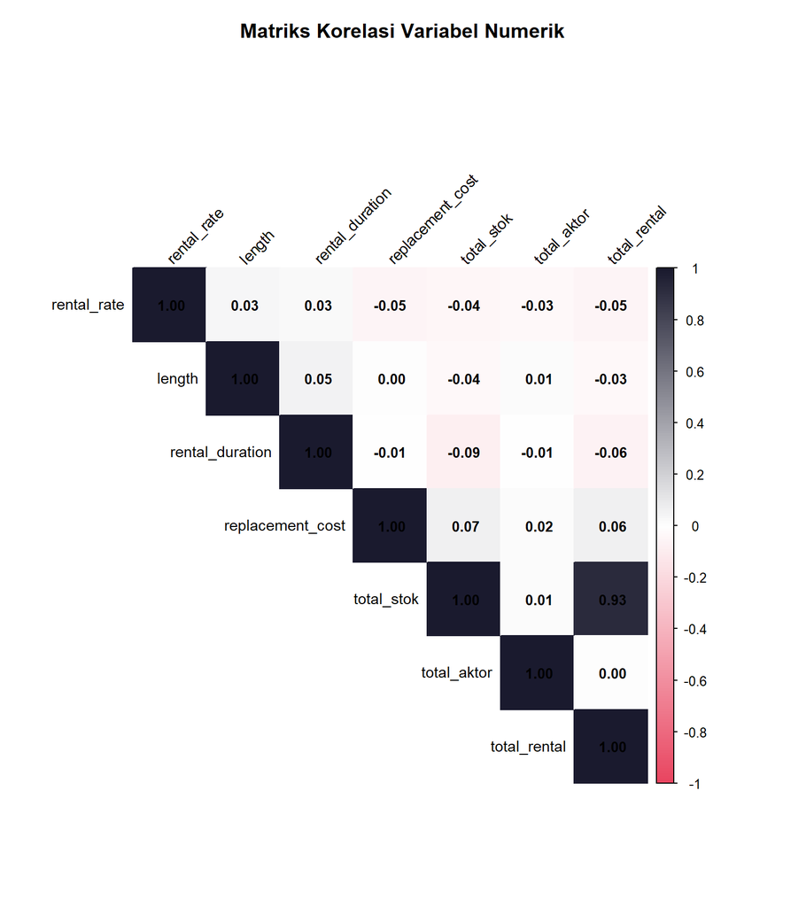

```r
cor_matrix <- cor(df_num, use = "complete.obs")

par(mar = c(0, 0, 3, 0))
corrplot(cor_matrix,
         method      = "color",
         type        = "upper",
         addCoef.col = "black",
         tl.col      = "black",
         tl.srt      = 45,
         tl.cex      = 0.9,
         number.cex  = 0.85,
         col         = colorRampPalette(
                         c("#e94560", "white", "#1a1a2e"))(200),
         title       = "Matriks Korelasi Variabel Numerik",
         mar         = c(0, 0, 3, 0))
```

## Analisis Regresi Linear Berganda

### Model Awal

Sebagai langkah pertama, dibangun model regresi awal menggunakan variabel dependen `total_rental` (tanpa transformasi) dengan seluruh prediktor yang tersedia. Model yang dibangun dapat diformulasikan sebagai berikut:

$$\hat{Y} = \beta_0 + \beta_1X_1 +
\beta_2X_2 + \beta_3X_3 + \beta_4X_4 + \beta_5X_5 + \beta_6X_6 +
\varepsilon$$

di mana:

- $\hat{Y}$ = prediksi `total_rental`
- $X_1$ = `rental_rate`, $X_2$ = `length`, $X_3$ = `rental_duration`
- $X_4$ = `replacement_cost`, $X_5$ = `total_stok`, $X_6$ = `total_aktor`
- $\varepsilon$ = *error term*

```r
df_film$rating <- factor(df_film$rating,
                          levels = c("G", "PG", "PG-13", "R", "NC-17"))

model_awal <- lm(total_rental ~ rental_rate + length +
                   rental_duration + replacement_cost +
                   rating + total_stok + total_aktor,
                 data = df_film)

summary(model_awal)
```

```
##
## Call:
## lm(formula = total_rental ~ rental_rate + length + rental_duration +
##     replacement_cost + rating + total_stok + total_aktor, data = df_film)
##
## Residuals:
##     Min      1Q  Median      3Q     Max
## -8.0947 -1.5413 -0.0922  1.5863  6.9677
##
## Coefficients:
##                    Estimate Std. Error t value Pr(>|t|)
## (Intercept)       0.0825336  0.5763037   0.143    0.886
## rental_rate      -0.0542495  0.0488142  -1.111    0.267
## length            0.0002224  0.0019886   0.112    0.911
## rental_duration   0.1034153  0.0574165   1.801    0.072 .
## replacement_cost  0.0002468  0.0132802   0.019    0.985
## ratingPG         -0.1076986  0.2646380  -0.407    0.684
## ratingPG-13       0.0695069  0.2549097   0.273    0.785
## ratingR           0.1119648  0.2619287   0.427    0.669
## ratingNC-17      -0.1052441  0.2573836  -0.409    0.683
## total_stok        3.4271422  0.0444430  77.113   <2e-16 ***
## total_aktor      -0.0165914  0.0346744  -0.478    0.632
## ---
## Signif. codes:  0 '***' 0.001 '**' 0.01 '*' 0.05 '.' 0.1 ' ' 1
##
## Residual standard error: 2.466 on 944 degrees of freedom
## Multiple R-squared:  0.8653, Adjusted R-squared:  0.8639
## F-statistic: 606.3 on 10 and 944 DF,  p-value: < 2.2e-16
```

Koefisien Model Regresi Awal

Variabel

Koefisien

Std. Error

t-value

p-value

Signifikan

(Intercept)

0.0825

0.5763

0.1432

0.8862

rental_rate

-0.0542

0.0488

-1.1113

0.2667

length

0.0002

0.0020

0.1119

0.9110

rental_duration

0.1034

0.0574

1.8011

0.0720

.

replacement_cost

0.0002

0.0133

0.0186

0.9852

ratingPG

-0.1077

0.2646

-0.4070

0.6841

ratingPG-13

0.0695

0.2549

0.2727

0.7852

ratingR

0.1120

0.2619

0.4275

0.6691

ratingNC-17

-0.1052

0.2574

-0.4089

0.6827

total_stok

3.4271

0.0444

77.1133

0.0000

***

total_aktor

-0.0166

0.0347

-0.4785

0.6324

Model awal menghasilkan **R-squared = 0.865** yang berarti model mampu menjelaskan 86.5% variasi `total_rental`. Variabel `total_stok` menjadi satu-satunya prediktor yang sangat signifikan (p < 2e-16), sementara prediktor lainnya tidak signifikan. Meski R-squared tinggi, perlu dilakukan uji asumsi klasik untuk memvalidasi kelayakan model.

### Uji Asumsi Model Awal

```r
# 1. VIF
cat("=== UJI VIF ===\n")
```

```
## === UJI VIF ===
```

```r
car::vif(model_awal)
```

```
##                      GVIF Df GVIF^(1/(2*Df))
## rental_rate      1.008059  1        1.004022
## length           1.014371  1        1.007160
## rental_duration  1.021669  1        1.010776
## replacement_cost 1.015723  1        1.007831
## rating           1.044061  4        1.005404
## total_stok       1.022395  1        1.011135
## total_aktor      1.009198  1        1.004588
```

```r
# 2. Breusch-Pagan
cat("\n=== UJI BREUSCH-PAGAN ===\n")
```

```
##
## === UJI BREUSCH-PAGAN ===
```

```r
bptest(model_awal)
```

```
##
##  studentized Breusch-Pagan test
##
## data:  model_awal
## BP = 90.426, df = 10, p-value = 4.409e-15
```

```r
# 3. Shapiro-Wilk
cat("\n=== UJI SHAPIRO-WILK ===\n")
```

```
##
## === UJI SHAPIRO-WILK ===
```

```r
shapiro.test(residuals(model_awal))
```

```
##
##  Shapiro-Wilk normality test
##
## data:  residuals(model_awal)
## W = 0.99791, p-value = 0.2822
```

```r
# 4. Durbin-Watson
cat("\n=== UJI DURBIN-WATSON ===\n")
```

```
##
## === UJI DURBIN-WATSON ===
```

```r
dwtest(model_awal)
```

```
##
##  Durbin-Watson test
##
## data:  model_awal
## DW = 1.9654, p-value = 0.2961
## alternative hypothesis: true autocorrelation is greater than 0
```

```r
# 5. Rainbow
cat("\n=== UJI RAINBOW ===\n")
```

```
##
## === UJI RAINBOW ===
```

```r
raintest(model_awal)
```

```
##
##  Rainbow test
##
## data:  model_awal
## Rain = 0.99576, df1 = 478, df2 = 466, p-value = 0.5185
```

### Model Final (Setelah Perbaikan)

Untuk mengatasi pelanggaran asumsi, diterapkan dua perbaikan:

1. **Transformasi logaritma** pada variabel dependen `total_rental` → `log_total_rental` untuk menstabilkan varians residual
2. **Robust Standard Errors (HC3)** untuk mengoreksi heteroskedastisitas yang tersisa

Model final diformulasikan sebagai:

$$\log(\hat{Y}) = \beta_0 + \beta_1X_1 +
\beta_2X_2 + \beta_3X_3 + \beta_4X_4 + \beta_5X_5 + \beta_6X_6 +
\varepsilon$$

```r
# Transformasi log
df_film$log_total_rental <- log(df_film$total_rental)

model_regresi <- lm(log_total_rental ~ rental_rate + length +
                      rental_duration + replacement_cost +
                      rating + total_stok + total_aktor,
                    data = df_film)

# Hasil dengan Robust SE
coeftest(model_regresi, vcov = vcovHC(model_regresi, type = "HC3"))
```

```
##
## t test of coefficients:
##
##                     Estimate  Std. Error t value Pr(>|t|)
## (Intercept)       1.6222e+00  4.2973e-02 37.7488   <2e-16 ***
## rental_rate      -3.8052e-03  3.5211e-03 -1.0807   0.2801
## length            7.2673e-05  1.5210e-04  0.4778   0.6329
## rental_duration   4.9070e-03  4.1923e-03  1.1705   0.2421
## replacement_cost -5.8771e-04  9.8331e-04 -0.5977   0.5502
## ratingPG          1.0469e-02  1.9683e-02  0.5319   0.5949
## ratingPG-13       1.4279e-02  1.9586e-02  0.7290   0.4662
## ratingR           1.5273e-02  2.0873e-02  0.7317   0.4645
## ratingNC-17      -2.6830e-03  1.8914e-02 -0.1419   0.8872
## total_stok        2.2686e-01  3.6610e-03 61.9670   <2e-16 ***
## total_aktor       5.1064e-04  2.3715e-03  0.2153   0.8296
## ---
## Signif. codes:  0 '***' 0.001 '**' 0.01 '*' 0.05 '.' 0.1 ' ' 1
```

Koefisien Model Final (Robust SE HC3)

Variabel

Koefisien

Std.Error

t.value

p.value

Signifikan

(Intercept)

1.6222

0.0430

37.7488

0.0000

***

rental_rate

-0.0038

0.0035

-1.0807

0.2801

length

0.0001

0.0002

0.4778

0.6329

rental_duration

0.0049

0.0042

1.1705

0.2421

replacement_cost

-0.0006

0.0010

-0.5977

0.5502

ratingPG

0.0105

0.0197

0.5319

0.5949

ratingPG-13

0.0143

0.0196

0.7290

0.4662

ratingR

0.0153

0.0209

0.7317

0.4645

ratingNC-17

-0.0027

0.0189

-0.1419

0.8872

total_stok

0.2269

0.0037

61.9670

0.0000

***

total_aktor

0.0005

0.0024

0.2153

0.8296

### Uji Asumsi Model Final

```r
# 1. VIF
cat("=== UJI VIF ===\n")
```

```
## === UJI VIF ===
```

```r
car::vif(model_regresi)
```

```
##                      GVIF Df GVIF^(1/(2*Df))
## rental_rate      1.008059  1        1.004022
## length           1.014371  1        1.007160
## rental_duration  1.021669  1        1.010776
## replacement_cost 1.015723  1        1.007831
## rating           1.044061  4        1.005404
## total_stok       1.022395  1        1.011135
## total_aktor      1.009198  1        1.004588
```

```r
# 2. Breusch-Pagan
cat("\n=== UJI BREUSCH-PAGAN (dikoreksi Robust SE) ===\n")
```

```
##
## === UJI BREUSCH-PAGAN (dikoreksi Robust SE) ===
```

```r
bptest(model_regresi)
```

```
##
##  studentized Breusch-Pagan test
##
## data:  model_regresi
## BP = 65.806, df = 10, p-value = 2.842e-10
```

```r
# 3. Kolmogorov-Smirnov
cat("\n=== UJI KOLMOGOROV-SMIRNOV ===\n")
```

```
##
## === UJI KOLMOGOROV-SMIRNOV ===
```

```r
ks.test(residuals(model_regresi), "pnorm",
        mean = mean(residuals(model_regresi)),
        sd   = sd(residuals(model_regresi)))
```

```
##
##  Asymptotic one-sample Kolmogorov-Smirnov test
##
## data:  residuals(model_regresi)
## D = 0.040416, p-value = 0.08832
## alternative hypothesis: two-sided
```

```r
# 4. Durbin-Watson
cat("\n=== UJI DURBIN-WATSON ===\n")
```

```
##
## === UJI DURBIN-WATSON ===
```

```r
dwtest(model_regresi)
```

```
##
##  Durbin-Watson test
##
## data:  model_regresi
## DW = 1.9433, p-value = 0.19
## alternative hypothesis: true autocorrelation is greater than 0
```

```r
# 5. Rainbow
cat("\n=== UJI RAINBOW ===\n")
```

```
##
## === UJI RAINBOW ===
```

```r
raintest(model_regresi)
```

```
##
##  Rainbow test
##
## data:  model_regresi
## Rain = 0.97016, df1 = 478, df2 = 466, p-value = 0.629
```

Ringkasan Uji Asumsi Klasik Model Final

Uji

Statistik

p.value

Kesimpulan

Multikolinearitas (GVIF)

1.0111

Tidak ada multikolinearitas (GVIF < 2) ✓

Heteroskedastisitas (Breusch-Pagan)

65.8056

0

Dikoreksi dengan Robust SE HC3 ✓

Normalitas Residual (Kolmogorov-Smirnov)

0.0404

0.0883

Residual normal (p > 0.05) ✓

Autokorelasi (Durbin-Watson)

1.9433

0.19

Tidak ada autokorelasi (p > 0.05) ✓

Linearitas (Rainbow Test)

0.9702

0.629

Hubungan linear (p > 0.05) ✓

## K-Means Clustering

Sebagai metode komplementer dari regresi, K-Means Clustering diterapkan untuk mengelompokkan film ke dalam segmen-segmen strategis berdasarkan karakteristik numeriknya. Berbeda dengan regresi yang berfokus pada hubungan sebab-akibat, clustering berfokus pada **kesamaan pola** antar film tanpa memerlukan variabel dependen.

Variabel yang digunakan dalam proses clustering adalah:

- `total_rental` — tingkat popularitas/permintaan film
- `rental_rate` — harga sewa film
- `replacement_cost` — nilai/kelas film
- `total_stok` — ketersediaan fisik film

### Preprocessing: Scaling Data

Sebelum clustering dilakukan, seluruh variabel dinormalisasi menggunakan **Z-score standardization** agar perbedaan skala antar variabel tidak mendominasi perhitungan jarak Euclidean:
$$z_i = \frac{x_i - \bar{x}}{s}$$

```r
df_cluster <- df_film %>%
  select(film_id, title, total_rental, rental_rate,
         replacement_cost, total_stok)

# Scaling Z-score
df_scaled <- scale(df_cluster %>%
                     select(total_rental, rental_rate,
                            replacement_cost, total_stok))

rownames(df_scaled) <- df_cluster$title
```

### Penentuan Jumlah Klaster Optimal

#### Metode Elbow

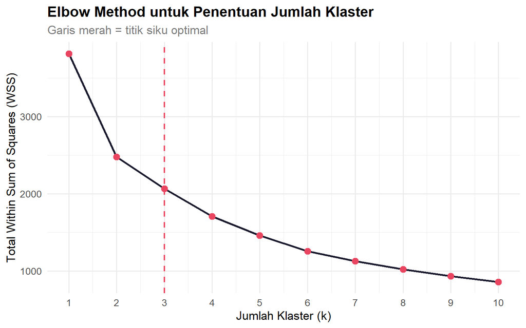

```r
set.seed(42)

wss <- sapply(1:10, function(k) {
  kmeans(df_scaled, centers = k, nstart = 25)$tot.withinss
})

elbow_df <- data.frame(k = 1:10, wss = wss)

ggplot(elbow_df, aes(x = k, y = wss)) +
  geom_line(color = "#1a1a2e", linewidth = 1) +
  geom_point(color = "#e94560", size = 3) +
  geom_vline(xintercept = 3, linetype = "dashed",
             color = "#e94560", linewidth = 0.8) +
  scale_x_continuous(breaks = 1:10) +
  labs(
    title    = "Elbow Method untuk Penentuan Jumlah Klaster",
    subtitle = "Garis merah = titik siku optimal",
    x        = "Jumlah Klaster (k)",
    y        = "Total Within Sum of Squares (WSS)"
  ) +
  theme_minimal(base_size = 13) +
  theme(
    plot.title    = element_text(face = "bold"),
    plot.subtitle = element_text(color = "gray50")
  )
```

#### Indeks Silhouette

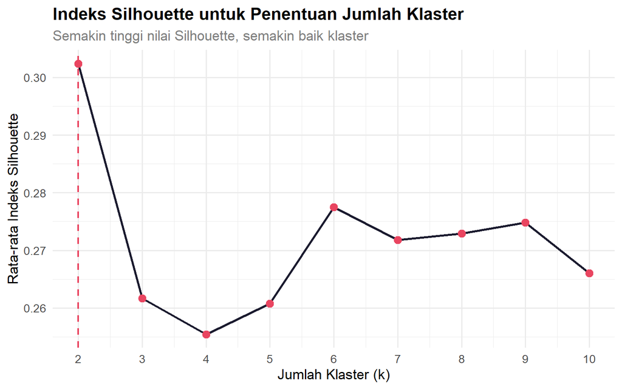

```r
set.seed(42)

sil_scores <- sapply(2:10, function(k) {
  km  <- kmeans(df_scaled, centers = k, nstart = 25)
  sil <- silhouette(km$cluster, dist(df_scaled))
  mean(sil[, 3])
})

sil_df <- data.frame(k = 2:10, sil = sil_scores)

ggplot(sil_df, aes(x = k, y = sil)) +
  geom_line(color = "#1a1a2e", linewidth = 1) +
  geom_point(color = "#e94560", size = 3) +
  geom_vline(xintercept = sil_df$k[which.max(sil_df$sil)],
             linetype = "dashed", color = "#e94560", linewidth = 0.8) +
  scale_x_continuous(breaks = 2:10) +
  labs(
    title    = "Indeks Silhouette untuk Penentuan Jumlah Klaster",
    subtitle = "Semakin tinggi nilai Silhouette, semakin baik klaster",
    x        = "Jumlah Klaster (k)",
    y        = "Rata-rata Indeks Silhouette"
  ) +
  theme_minimal(base_size = 13) +
  theme(
    plot.title    = element_text(face = "bold"),
    plot.subtitle = element_text(color = "gray50")
  )
```

### Fitting Model K-Means

```r
set.seed(42)

km_final <- kmeans(df_scaled, centers = 3, nstart = 25)

# Tambahkan label klaster ke dataframe
df_cluster$klaster <- as.factor(km_final$cluster)

# Ringkasan tiap klaster
df_cluster %>%
  group_by(klaster) %>%
  summarise(
    n_film         = n(),
    avg_rental     = round(mean(total_rental), 2),
    avg_rate       = round(mean(rental_rate), 2),
    avg_cost       = round(mean(replacement_cost), 2),
    avg_stok       = round(mean(total_stok), 2)
  ) %>%
  kable(caption = "Ringkasan Karakteristik Tiap Klaster",
        col.names = c("Klaster", "Jumlah Film", "Avg Rental",
                      "Avg Rate", "Avg Cost", "Avg Stok")) %>%
  kable_styling(
    bootstrap_options = c("striped", "hover", "bordered"),
    full_width        = TRUE,
    position          = "left"
  ) %>%
  row_spec(0, bold = TRUE, color = "white", background = "#16213e")
```

Ringkasan Karakteristik Tiap Klaster

| Klaster | Jumlah Film | Avg Rental | Avg Rate | Avg Cost | Avg Stok |
| --- | --- | --- | --- | --- | --- |
| 1 | 277 | 22.13 | 1.63 | 22.42 | 6.25 |
| 2 | 252 | 21.05 | 4.46 | 18.19 | 6.02 |
| 3 | 426 | 10.73 | 2.97 | 19.61 | 3.10 |

### Visualisasi Klaster

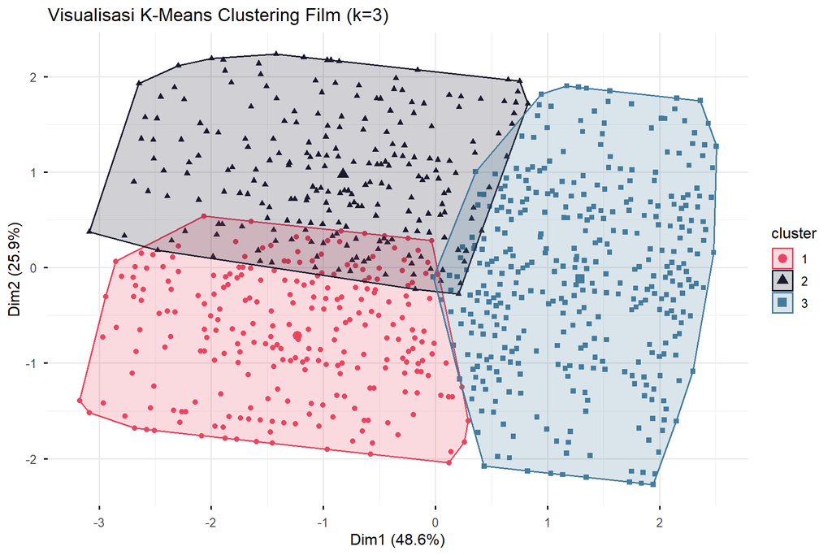

```r
fviz_cluster(km_final,
             data        = df_scaled,
             geom        = "point",
             ellipse     = TRUE,
             ellipse.type = "convex",
             palette     = c("#e94560", "#1a1a2e", "#457b9d"),
             ggtheme     = theme_minimal(base_size = 12),
             main        = "Visualisasi K-Means Clustering Film (k=3)")
```

### Interpretasi Hasil Clustering

**Klaster 1 — High Demand (277 film)** Rata-rata rental tertinggi (22.13 kali) dengan harga sewa terendah ($1.63) dan stok memadai (6.25 unit). Segmen ini merupakan **aset utama toko** — film paling diminati dengan harga terjangkau.

**Klaster 2 — Moderate Demand (252 film)** Rental tinggi (21.05 kali) namun harga sewa tertinggi ($4.46). Film **premium yang tetap diminati** meski harganya mahal.

**Klaster 3 — Low Demand (426 film)** Segmen terbesar (426 film) dengan rental terendah (10.73 kali) dan stok paling sedikit (3.10 unit). Rendahnya permintaan kemungkinan besar disebabkan **keterbatasan stok**, bukan faktor harga.

Plot clustering menunjukkan ketiga klaster terpisah cukup jelas dengan total variansi yang dijelaskan sebesar **74.5%** (Dim1 + Dim2).

### Pelabelan Segmen

Berdasarkan karakteristik rata-rata tiap klaster, setiap klaster diberi label yang mencerminkan posisi strategisnya:

```r
# Sesuaikan label berdasarkan output ringkasan klaster kamu
label_map <- c("1" = "High Demand",
               "2" = "Moderate Demand",
               "3" = "Low Demand")

df_cluster$segmen <- label_map[as.character(df_cluster$klaster)]
df_cluster$segmen <- factor(df_cluster$segmen,
                             levels = c("High Demand",
                                        "Moderate Demand",
                                        "Low Demand"))
```

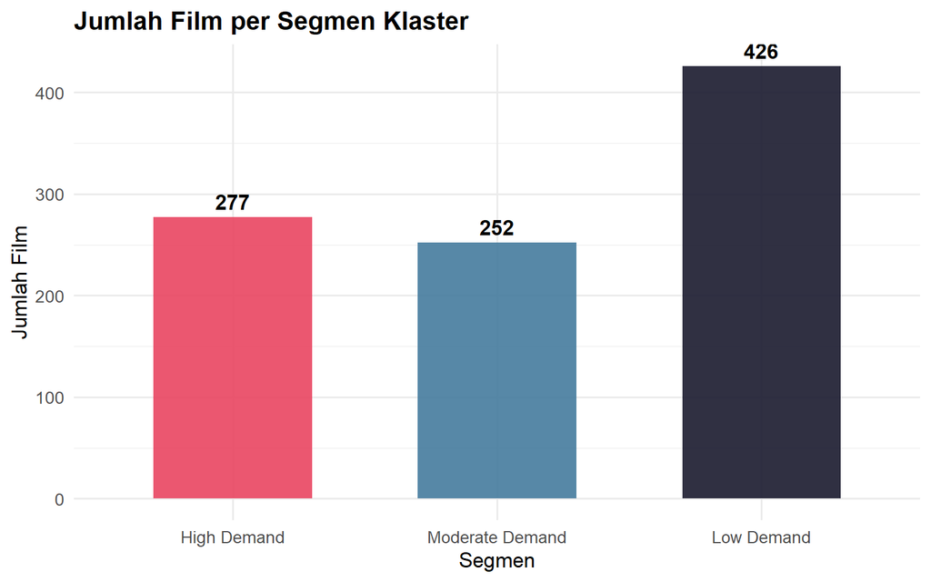

```r
df_cluster %>%
  count(segmen) %>%
  ggplot(aes(x = segmen, y = n, fill = segmen)) +
  geom_bar(stat = "identity", width = 0.6, alpha = 0.9) +
  geom_text(aes(label = n), vjust = -0.5, fontface = "bold", size = 4.5) +
  scale_fill_manual(values = c("#e94560", "#457b9d", "#1a1a2e")) +
  labs(
    title = "Jumlah Film per Segmen Klaster",
    x     = "Segmen",
    y     = "Jumlah Film"
  ) +
  theme_minimal(base_size = 13) +
  theme(
    legend.position = "none",
    plot.title      = element_text(face = "bold")
  )
```

# Kesimpulan dan Rekomendasi Bisnis

## Kesimpulan

Analisis terhadap database Sakila menggunakan dua metode kuantitatif menghasilkan beberapa temuan utama:

**1. Regresi Linear Berganda**

Model regresi final dengan variabel dependen `log(total_rental)` menghasilkan **R-squared = 0.837**, artinya model mampu menjelaskan 83.7% variasi permintaan sewa film. Dari seluruh prediktor yang diuji, hanya **`total_stok`** yang terbukti signifikan secara statistik (p < 2e-16) dengan koefisien positif — setiap penambahan satu unit stok meningkatkan log permintaan sebesar 0.227. Variabel lain seperti `rental_rate`, `length`, `rental_duration`, `replacement_cost`, dan `rating` tidak signifikan, mengindikasikan bahwa **ketersediaan fisik film adalah penentu utama permintaan sewa**, bukan atribut intrinsik film.

**2. K-Means Clustering**

Pengelompokan film ke dalam tiga segmen menghasilkan struktur yang jelas dan bermakna secara bisnis:

- **High Demand (277 film):** rental tinggi, harga murah, stok memadai
- **Moderate Demand (252 film):** rental tinggi, harga mahal, stok memadai
- **Low Demand (426 film):** rental rendah, stok terbatas

Temuan clustering memperkuat hasil regresi — segmen Low Demand memiliki stok paling sedikit (3.10 unit) sekaligus rental terendah, membuktikan bahwa **stok adalah bottleneck utama** permintaan.

## Rekomendasi Bisnis

Rekomendasi Strategi Bisnis per Segmen

| Segmen | Strategi | Aksi yang Disarankan |
| --- | --- | --- |
| High Demand | Prioritas utama pengadaan stok | Tambah unit fisik, pastikan selalu tersedia, jadikan andalan promosi |
| Moderate Demand | Pertahankan stok, evaluasi elastisitas harga | Uji penurunan harga untuk mendorong volume rental lebih tinggi |
| Low Demand | Tambah stok secara selektif, evaluasi relevansi judul | Identifikasi judul potensial, tambah stok, pertimbangkan rotasi judul |

Secara keseluruhan, temuan analisis ini memberikan satu pesan bisnis yang konsisten: **investasi pada ketersediaan stok film** adalah lever paling efektif untuk meningkatkan total permintaan sewa. Pengelola toko sebaiknya memprioritaskan anggaran pengadaan pada film-film segmen *High Demand* sebagai revenue driver utama, sambil secara bertahap mengoptimalkan portofolio segmen *Low Demand* melalui rotasi judul yang lebih relevan dengan preferensi pelanggan.